# CSC 444 Data Visualization

September 01, 2022

## Agenda & Announcements

- Questions?
- No in-person class on Thursday
- Assignment 3 has been posted

## D3

## Getting the code

Go to [d3js.org](https://d3js.org/) and click on the compressed file under `Download the latest version here:`

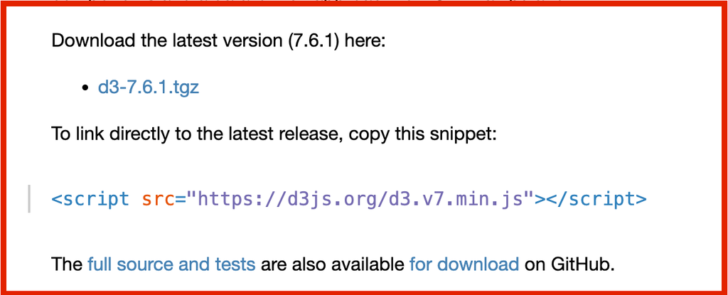

## Set up your working environment

1. Create a folder with a “source” folder and move the `d3.js` file to it
2. Create an index.html file and source d3.js to it
3. Create a forecast_barplot.js file with the following data:

```javascript
var forecasts = [
    { city: "DCA", temperature: 92,  order: 0 },
    { city: "JFK", temperature: 96,  order: 1 },
    { city: "SEA", temperature: 77,  order: 2 },
    { city: "TUS", temperature: 102, order: 3 },
    { city: "SFO", temperature: 65,  order: 4 }
];
```

## Appending elements

```javascript
// select main div
var mainDiv = d3.select("#mainDiv");

// append svg element and assign node to variable
var svg1 = mainDiv.append("svg").attr("height", 300).attr("width", 300);

// add rectangle to svg1
var rectangle2 = svg1.append("rect");
var rectangle2 = svg1.append("rect");

// set attributes for all svg elements
mainDiv.selectAll("rect").attr("width", 35)
                         .attr("height", 35)
                         .style("fill", "steelblue");
```

## Challenge

## Creating a barplot

Based on the forecast data, loop over each element, appending a `rect` to `svg1` setting the following attributes: `height` mapped to *temperature*, `x` mapped to *order* and `y` to the height of the canvas minus *temperature*

```javascript
forecasts.forEach(function(element) {
     svg1.append("rect")
                   .attr(_______, element.temperature)
                   .attr(_______, _______)
                   .attr(_______, _______ - _______);
});
```

## Data

## Joins

```javascript
// select main div
var mainDiv = d3.select("#mainDiv");

// append svg element and assign node to variable
var svg1 = mainDiv.append("svg");

// data
my_data = [{x: 10, y: 10}, {x: 20, y: 20}, {x: 30, y: 30}]

svg1.selectAll("circle")
  .data(my_data)
  .enter().append("circle")
  .attr("cx", function(d) { return d.x; })
  .attr("cy", function(d) { return d.y; })
  .attr("r", 2.5);
```

## Challenge

## UK Driver Fatalities

Using the data in driver_fatalities.js, draw a scatterplot using `.data(UkDriverFatalities).enter().append("circle"). ...`

Add the two axes.

## Scales

## Scales in D3

> “Scales are functions that map from an input domain to an output range.”

– Mike Bostock

- Problem: values in data does not match x and y coordinates on the SVG canvas
- Solution: transform data in a consistent manner (a.k.a. normalization), with the following definitions
  - input **domain**: range of possible input data values
  - output **range**: range of possible output values (in pixels)

## Scales in D3

```javascript
// create a 1:1 scale
var my_scale = d3.scaleLinear();

my_scale(2.5); // returns input value because it's a 1:1 scale
```

## Scales in D3

```javascript
// set domain and range
my_scale.domain([100, 500]);
my_scale.range([10, 350]);
```

You can also do all together

```javascript
var my_scale = d3.scaleLinear()
              .domain([100, 500])
              .range([10, 350]);

my_scale(100); // returns 10
my_scale(500); // returns 350
```

## Scales in D3

To create your scale you need to know your domain – which is the range, or the min and max values in your data variable. Instead of doing this by hand, we will use `d3.min()` and `d3.max()`

```javascript
var simpleDataset = [7, 8, 4, 5, 2];
d3.max(simpleDataset);  // returns 8
d3.min(simpleDataset); // returns 2
```

## Scales in D3

For data that is organized as `json` or a dictionary, like it is the case for our ukDriverFatalities data, we need to use a function to return that specific variable for all objects.

```javascript
d3.max(ukDriverFatalities, function(d) {return d.count});
```

## Challenge

## Scales in D3

Modify your driver_fatalities code so you use scales instead

```javascript
// create two scales, one for y and one for x
var scale_year = d3.scaleLinear() ...

var scale_count = d3.scaleLinear() ...
```

Remember that for the domain you can get the max and min from your data

```javascript
d3.min(ukDriverFatalities, function(d) {return d.year})
```

And to call your scales, you can use something like this:

```javascript
function(d) { return scale_year(d.year); }
```

## D3 axes

## Using D3 axis methods

```javascript
// create a y (left) axis with the scale we created
var y_axis = d3.axisLeft().scale(scale_count);

// append a group to our SVG that is a little dislocated
// add our axis to it
svg1.append("g")
       .attr("transform", "translate(50, 50)")
       .call(y_axis);
```

## Reading data

## CSV

```javascript
d3.csv("https://raw.githubusercontent.com/picoral/csc-444-data/main/anscombe_tidy.csv",
       function(data) {
         console.log(data);
         });
```